# Peer Assessment 1 Reproducible Research

Isaac N B

02 July 2016

1- Load the data (i.e. read.csv()) Process/transform the data (if necessary) into a format suitable for your analysis

```r
data <- read.csv("activity.csv")
str(data)
```

```
## 'data.frame':    17568 obs. of  3 variables:
##  $ steps   : int  NA NA NA NA NA NA NA NA NA NA ...
##  $ date    : Factor w/ 61 levels "2012-10-01","2012-10-02",..: 1 1 1 1 1 1 1 1 1 1 ...
##  $ interval: int  0 5 10 15 20 25 30 35 40 45 ...
```

```r
head(data)
```

```
##   steps       date interval
## 1    NA 2012-10-01        0
## 2    NA 2012-10-01        5
## 3    NA 2012-10-01       10
## 4    NA 2012-10-01       15
## 5    NA 2012-10-01       20
## 6    NA 2012-10-01       25
```

```r
attach(data)
totalPerDay <- tapply(steps,list(date),sum)
detach(data)
```

2- What is mean total number of steps taken per day? For this part of the assignment the missing values can be ignored.

Calculate the total number of steps taken per day. Make a histogram of the total number of steps taken each day. Calculate and report the mean and median of the total number of steps taken per day.

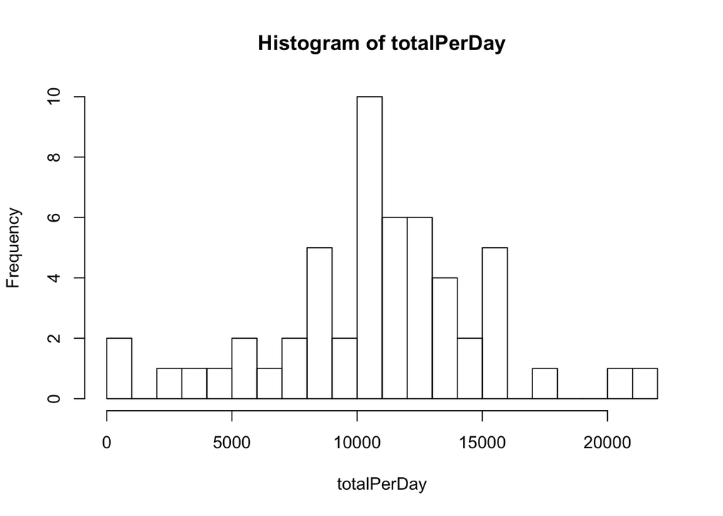

```r
hist(totalPerDay,breaks=20)
```

```r
meanPerDay = mean(totalPerDay,na.rm = TRUE)
meanPerDay
```

```
## [1] 10766.19
```

```r
medianPerDay <- median(totalPerDay,na.rm = TRUE)
medianPerDay
```

```
## [1] 10765
```

3- What is the average daily activity pattern?

Make a time series plot (i.e. type = “l”) of the 5-minute interval (x-axis) and the average number of steps taken, averaged across all days (y-axis) Which 5-minute interval, on average across all the days in the dataset, contains the maximum number of steps?

```r
attach(data)
meanEvery5min <- tapply(steps,list(interval),mean,na.rm=TRUE)
detach(data)
```

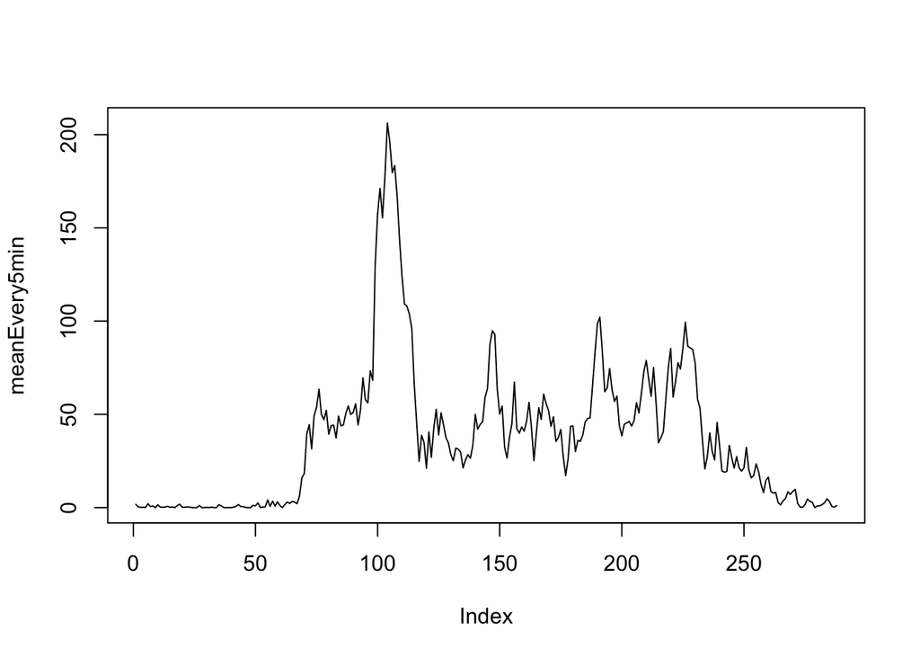

```r
plot(meanEvery5min,type="l")
```

```r
which.max(meanEvery5min)
```

```
## 835
## 104
```

```r
meanEvery5min[104]
```

```
##      835
## 206.1698
```

```r
max(meanEvery5min)
```

```
## [1] 206.1698
```

4-Imputing missing values

found the total number of missing values in the dataset

```r
calMissing <- sum(is.na(data$steps))
calMissing
```

```
## [1] 2304
```

```r
na <- is.na(data$steps)
shiftmeanEvery5min <- c(meanEvery5min[288],meanEvery5min[1:287])
imputedSteps <- rep(0,length(data$steps))
for (i in 1:length(data$steps))
{
  if(na[i])
    {
      imputedSteps[i] <- shiftmeanEvery5min[i%%length(meanEvery5min)+1]
    }
  else
    {
      imputedSteps[i] <- data$steps[i]
    }
}

#data <- transform(data, data$imputedSteps = imputedSteps)
data <- cbind(data,imputedSteps)
str(data)
```

```
## 'data.frame':    17568 obs. of  4 variables:
##  $ steps       : int  NA NA NA NA NA NA NA NA NA NA ...
##  $ date        : Factor w/ 61 levels "2012-10-01","2012-10-02",..: 1 1 1 1 1 1 1 1 1 1 ...
##  $ interval    : int  0 5 10 15 20 25 30 35 40 45 ...
##  $ imputedSteps: num  1.717 0.3396 0.1321 0.1509 0.0755 ...
```

```r
head(data)
```

```
##   steps       date interval imputedSteps
## 1    NA 2012-10-01        0    1.7169811
## 2    NA 2012-10-01        5    0.3396226
## 3    NA 2012-10-01       10    0.1320755
## 4    NA 2012-10-01       15    0.1509434
## 5    NA 2012-10-01       20    0.0754717
## 6    NA 2012-10-01       25    2.0943396
```

Make a histogram of the total number of steps taken each day

```r
attach(data)
```

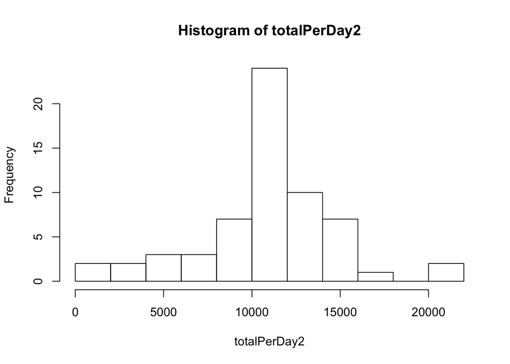

```r
totalPerDay2 <- tapply(imputedSteps,list(date),sum)
detach(data)
hist(totalPerDay2,breaks=10)
```

```r
mean(totalPerDay2)
```

```
## [1] 10766.19
```

```r
median(totalPerDay2)
```

```
## [1] 10766.19
```

We found that the mean and median value in the data not differ very much from in the original data. same as the histogram does not differ too much with the histogram of the original data .

Are there differences in activity patterns between weekdays and weekends?

```r
date <- levels(data$date)
daytype <- weekdays(as.Date(date))
for(i in 1:length(daytype))
  {
    if(daytype[i] %in% c("Monday", "Tuesday", "Wednesday", "Thursday", "Friday"))
      {
        daytype[i] <- "weekday"
      }
    else
      {
        daytype[i] <- "weekend"
      }
  }
daytype <- as.factor(daytype)
isweekday <- rep(daytype,each=length(meanEvery5min))

data <- cbind(data,isweekday)
str(data)
```

```
## 'data.frame':    17568 obs. of  5 variables:
##  $ steps       : int  NA NA NA NA NA NA NA NA NA NA ...
##  $ date        : Factor w/ 61 levels "2012-10-01","2012-10-02",..: 1 1 1 1 1 1 1 1 1 1 ...
##  $ interval    : int  0 5 10 15 20 25 30 35 40 45 ...
##  $ imputedSteps: num  1.717 0.3396 0.1321 0.1509 0.0755 ...
##  $ isweekday   : Factor w/ 2 levels "weekday","weekend": 1 1 1 1 1 1 1 1 1 1 ...
```

```r
head(data)
```

```
##   steps       date interval imputedSteps isweekday
## 1    NA 2012-10-01        0    1.7169811   weekday
## 2    NA 2012-10-01        5    0.3396226   weekday
## 3    NA 2012-10-01       10    0.1320755   weekday
## 4    NA 2012-10-01       15    0.1509434   weekday
## 5    NA 2012-10-01       20    0.0754717   weekday
## 6    NA 2012-10-01       25    2.0943396   weekday
```

```r
attach(data)
daytypeDiff <- aggregate(imputedSteps, list(interval,isweekday), mean)
detach(data)
library(lattice)
```

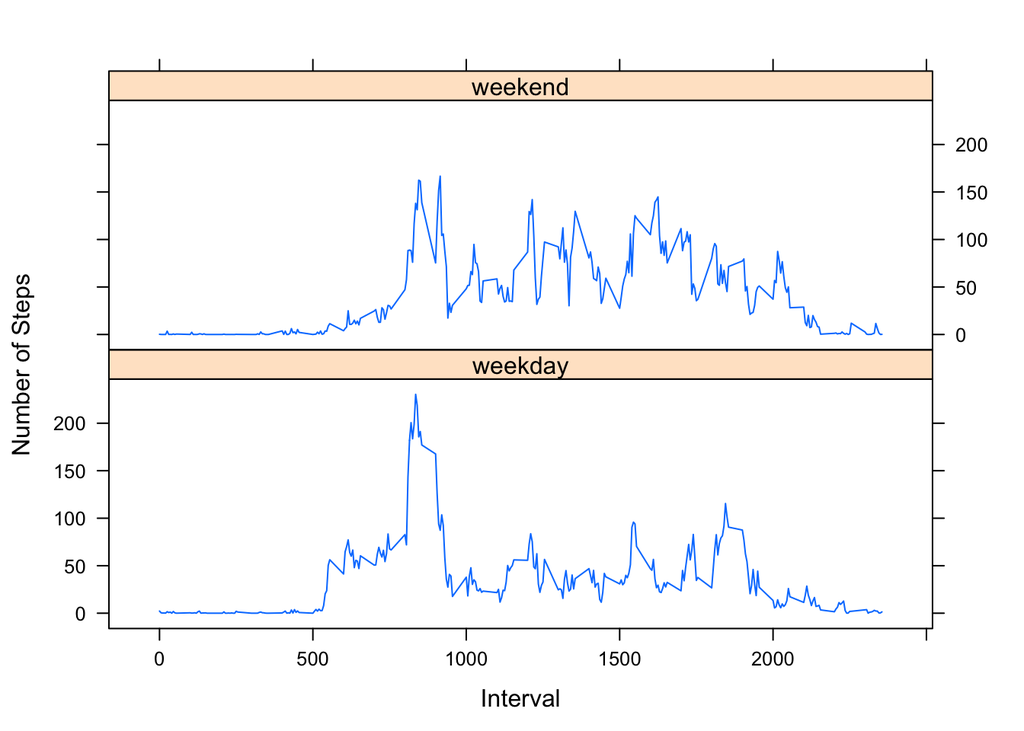

```r
xyplot(x ~ Group.1|Group.2,data=daytypeDiff,type="l",layout=c(1,2),xlab="Interval",ylab="Number of Steps")
```